# ANCOVA in Vocabulario Ensinado (Vocabulario Ensinado)

Geiser C. Challco geiser@alumni.usp.br

- Descriptive Statistics of Initial Data
- ANCOVA and Pairwise for one factor: **grupo**
  - Without remove non-normal data
  - Computing ANCOVA and PairWise After removing non-normal data (OK)
    - Plots for ancova
    - Checking linearity assumption
    - Checking normality and homogeneity
- ANCOVA and Pairwise for two factors **grupo:Sexo**
  - Without remove non-normal data
  - Computing ANCOVA and PairWise After removing non-normal data (OK)
    - Plots for ancova
    - Checking linearity assumption
    - Checking normality and homogeneity
- ANCOVA and Pairwise for two factors **grupo:Zona**
  - Without remove non-normal data
  - Computing ANCOVA and PairWise After removing non-normal data (OK)
    - Plots for ancova
    - Checking linearity assumption
    - Checking normality and homogeneity
- ANCOVA and Pairwise for two factors **grupo:Cor.Raca**
  - Without remove non-normal data
  - Computing ANCOVA and PairWise After removing non-normal data (OK)
    - Plots for ancova
    - Checking linearity assumption
    - Checking normality and homogeneity
- ANCOVA and Pairwise for two factors **grupo:Serie**
  - Without remove non-normal data
  - Computing ANCOVA and PairWise After removing non-normal data (OK)
    - Plots for ancova
    - Checking linearity assumption
    - Checking normality and homogeneity
- Summary of Results
  - Descriptive Statistics
  - ANCOVA Table Comparison
  - PairWise Table Comparison
  - EMMS Table Comparison

**NOTE**:

- Teste ANCOVA para determinar se houve diferenças significativas no Vocabulario Ensinado (medido usando pre- e pos-testes).
- ANCOVA test to determine whether there were significant differences in Vocabulario Ensinado (measured using pre- and post-tests).

# Descriptive Statistics of Initial Data

```r
df <- get.descriptives(dat, c(dv.pre, dv.pos), c("grupo"),
                       include.global = T, symmetry.test = T, normality.test = F)
df <- plyr::rbind.fill(
  df, do.call(plyr::rbind.fill, lapply(lfatores2, FUN = function(f) {
    if (nrow(dat) > 0 && sum(!is.na(unique(dat[[f]]))) > 1)
      get.descriptives(dat, c(dv.pre,dv.pos), c("grupo", f),
                       symmetry.test = T, normality.test = F)
    }))
)
(df <- df[,c(fatores1[fatores1 %in% colnames(df)],"variable",
             colnames(df)[!colnames(df) %in% c(fatores1,"variable")])])
```

```
##           grupo Sexo   Zona Cor.Raca Serie        variable   n  mean median min max    sd    se    ci
## 1      Controle <NA>   <NA>     <NA>  <NA> vocab.teach.pre 102 1.618    2.0   0   2 0.598 0.059 0.117
## 2  Experimental <NA>   <NA>     <NA>  <NA> vocab.teach.pre  93 1.710    2.0   0   2 0.480 0.050 0.099
## 3          <NA> <NA>   <NA>     <NA>  <NA> vocab.teach.pre 195 1.662    2.0   0   2 0.545 0.039 0.077
## 4      Controle <NA>   <NA>     <NA>  <NA> vocab.teach.pos 102 3.431    3.0   0  10 1.927 0.191 0.378
## 5  Experimental <NA>   <NA>     <NA>  <NA> vocab.teach.pos  93 3.871    3.0   1  10 1.946 0.202 0.401
## 6          <NA> <NA>   <NA>     <NA>  <NA> vocab.teach.pos 195 3.641    3.0   0  10 1.944 0.139 0.275
## 7      Controle    F   <NA>     <NA>  <NA> vocab.teach.pre  44 1.636    2.0   0   2 0.613 0.092 0.187
## 8      Controle    M   <NA>     <NA>  <NA> vocab.teach.pre  58 1.603    2.0   0   2 0.591 0.078 0.155
## 9  Experimental    F   <NA>     <NA>  <NA> vocab.teach.pre  50 1.660    2.0   0   2 0.519 0.073 0.148
## 10 Experimental    M   <NA>     <NA>  <NA> vocab.teach.pre  43 1.767    2.0   1   2 0.427 0.065 0.132
## 11     Controle    F   <NA>     <NA>  <NA> vocab.teach.pos  44 3.614    4.0   0  10 2.137 0.322 0.650
## 12     Controle    M   <NA>     <NA>  <NA> vocab.teach.pos  58 3.293    3.0   0   7 1.757 0.231 0.462
## 13 Experimental    F   <NA>     <NA>  <NA> vocab.teach.pos  50 4.220    4.0   1   8 1.753 0.248 0.498
## 14 Experimental    M   <NA>     <NA>  <NA> vocab.teach.pos  43 3.465    3.0   1  10 2.097 0.320 0.645
```

[output cut: 98 more lines]

| grupo | Sexo | Zona | Cor.Raca | Serie | variable | n | mean | median | min | max | sd | se | ci | iqr | symmetry | skewness | kurtosis |
| --- | --- | --- | --- | --- | --- | --- | --- | --- | --- | --- | --- | --- | --- | --- | --- | --- | --- |
| Controle |  |  |  |  | vocab.teach.pre | 102 | 1.618 | 2.0 | 0 | 2 | 0.598 | 0.059 | 0.117 | 1.00 | few data | 0.000 | 0.000 |
| Experimental |  |  |  |  | vocab.teach.pre | 93 | 1.710 | 2.0 | 0 | 2 | 0.480 | 0.050 | 0.099 | 1.00 | few data | 0.000 | 0.000 |
|  |  |  |  |  | vocab.teach.pre | 195 | 1.662 | 2.0 | 0 | 2 | 0.545 | 0.039 | 0.077 | 1.00 | few data | 0.000 | 0.000 |
| Controle |  |  |  |  | vocab.teach.pos | 102 | 3.431 | 3.0 | 0 | 10 | 1.927 | 0.191 | 0.378 | 2.75 | YES | 0.412 | 0.170 |
| Experimental |  |  |  |  | vocab.teach.pos | 93 | 3.871 | 3.0 | 1 | 10 | 1.946 | 0.202 | 0.401 | 2.00 | NO | 0.617 | -0.028 |
|  |  |  |  |  | vocab.teach.pos | 195 | 3.641 | 3.0 | 0 | 10 | 1.944 | 0.139 | 0.275 | 3.00 | NO | 0.509 | 0.151 |
| Controle | F |  |  |  | vocab.teach.pre | 44 | 1.636 | 2.0 | 0 | 2 | 0.613 | 0.092 | 0.187 | 1.00 | few data | 0.000 | 0.000 |
| Controle | M |  |  |  | vocab.teach.pre | 58 | 1.603 | 2.0 | 0 | 2 | 0.591 | 0.078 | 0.155 | 1.00 | few data | 0.000 | 0.000 |
| Experimental | F |  |  |  | vocab.teach.pre | 50 | 1.660 | 2.0 | 0 | 2 | 0.519 | 0.073 | 0.148 | 1.00 | few data | 0.000 | 0.000 |
| Experimental | M |  |  |  | vocab.teach.pre | 43 | 1.767 | 2.0 | 1 | 2 | 0.427 | 0.065 | 0.132 | 0.00 | few data | 0.000 | 0.000 |
| Controle | F |  |  |  | vocab.teach.pos | 44 | 3.614 | 4.0 | 0 | 10 | 2.137 | 0.322 | 0.650 | 3.00 | YES | 0.357 | 0.240 |
| Controle | M |  |  |  | vocab.teach.pos | 58 | 3.293 | 3.0 | 0 | 7 | 1.757 | 0.231 | 0.462 | 2.00 | YES | 0.358 | -0.516 |
| Experimental | F |  |  |  | vocab.teach.pos | 50 | 4.220 | 4.0 | 1 | 8 | 1.753 | 0.248 | 0.498 | 2.00 | YES | 0.294 | -0.680 |
| Experimental | M |  |  |  | vocab.teach.pos | 43 | 3.465 | 3.0 | 1 | 10 | 2.097 | 0.320 | 0.645 | 2.00 | NO | 1.039 | 0.769 |
| Controle |  | Rural |  |  | vocab.teach.pre | 49 | 1.694 | 2.0 | 0 | 2 | 0.548 | 0.078 | 0.157 | 1.00 | few data | 0.000 | 0.000 |
| Controle |  | Urbana |  |  | vocab.teach.pre | 20 | 1.650 | 2.0 | 0 | 2 | 0.671 | 0.150 | 0.314 | 0.25 | few data | 0.000 | 0.000 |
| Controle |  |  |  |  | vocab.teach.pre | 33 | 1.485 | 2.0 | 0 | 2 | 0.619 | 0.108 | 0.219 | 1.00 | few data | 0.000 | 0.000 |
| Experimental |  | Rural |  |  | vocab.teach.pre | 48 | 1.729 | 2.0 | 0 | 2 | 0.494 | 0.071 | 0.144 | 0.25 | few data | 0.000 | 0.000 |
| Experimental |  | Urbana |  |  | vocab.teach.pre | 25 | 1.680 | 2.0 | 1 | 2 | 0.476 | 0.095 | 0.197 | 1.00 | few data | 0.000 | 0.000 |
| Experimental |  |  |  |  | vocab.teach.pre | 20 | 1.700 | 2.0 | 1 | 2 | 0.470 | 0.105 | 0.220 | 1.00 | few data | 0.000 | 0.000 |
| Controle |  | Rural |  |  | vocab.teach.pos | 49 | 3.551 | 4.0 | 0 | 7 | 1.980 | 0.283 | 0.569 | 3.00 | YES | -0.011 | -1.011 |
| Controle |  | Urbana |  |  | vocab.teach.pos | 20 | 3.500 | 4.0 | 1 | 7 | 1.670 | 0.373 | 0.782 | 2.25 | YES | 0.129 | -0.833 |
| Controle |  |  |  |  | vocab.teach.pos | 33 | 3.212 | 3.0 | 0 | 10 | 2.027 | 0.353 | 0.719 | 2.00 | NO | 1.095 | 2.077 |
| Experimental |  | Rural |  |  | vocab.teach.pos | 48 | 3.979 | 3.5 | 1 | 10 | 2.088 | 0.301 | 0.606 | 2.00 | NO | 0.686 | -0.015 |
| Experimental |  | Urbana |  |  | vocab.teach.pos | 25 | 3.600 | 3.0 | 1 | 6 | 1.528 | 0.306 | 0.631 | 1.00 | YES | 0.256 | -0.928 |
| Experimental |  |  |  |  | vocab.teach.pos | 20 | 3.950 | 4.0 | 1 | 8 | 2.114 | 0.473 | 0.990 | 2.25 | YES | 0.316 | -1.020 |
| Controle |  |  | Branca |  | vocab.teach.pre | 14 | 1.714 | 2.0 | 1 | 2 | 0.469 | 0.125 | 0.271 | 0.75 | few data | 0.000 | 0.000 |
| Controle |  |  | Indígena |  | vocab.teach.pre | 1 | 1.000 | 1.0 | 1 | 1 |  |  |  | 0.00 | few data | 0.000 | 0.000 |
| Controle |  |  | Parda |  | vocab.teach.pre | 32 | 1.594 | 2.0 | 0 | 2 | 0.615 | 0.109 | 0.222 | 1.00 | few data | 0.000 | 0.000 |
| Controle |  |  |  |  | vocab.teach.pre | 55 | 1.618 | 2.0 | 0 | 2 | 0.623 | 0.084 | 0.169 | 1.00 | few data | 0.000 | 0.000 |
| Experimental |  |  | Branca |  | vocab.teach.pre | 6 | 1.833 | 2.0 | 1 | 2 | 0.408 | 0.167 | 0.428 | 0.00 | few data | 0.000 | 0.000 |
| Experimental |  |  | Indígena |  | vocab.teach.pre | 4 | 1.750 | 2.0 | 1 | 2 | 0.500 | 0.250 | 0.796 | 0.25 | few data | 0.000 | 0.000 |
| Experimental |  |  | Parda |  | vocab.teach.pre | 34 | 1.706 | 2.0 | 0 | 2 | 0.524 | 0.090 | 0.183 | 0.75 | few data | 0.000 | 0.000 |
| Experimental |  |  | Preta |  | vocab.teach.pre | 1 | 1.000 | 1.0 | 1 | 1 |  |  |  | 0.00 | few data | 0.000 | 0.000 |
| Experimental |  |  |  |  | vocab.teach.pre | 48 | 1.708 | 2.0 | 1 | 2 | 0.459 | 0.066 | 0.133 | 1.00 | few data | 0.000 | 0.000 |
| Controle |  |  | Branca |  | vocab.teach.pos | 14 | 3.857 | 4.0 | 1 | 7 | 1.703 | 0.455 | 0.983 | 1.75 | YES | 0.205 | -1.018 |
| Controle |  |  | Indígena |  | vocab.teach.pos | 1 | 6.000 | 6.0 | 6 | 6 |  |  |  | 0.00 | few data | 0.000 | 0.000 |
| Controle |  |  | Parda |  | vocab.teach.pos | 32 | 3.000 | 3.0 | 0 | 7 | 1.918 | 0.339 | 0.691 | 2.25 | YES | 0.186 | -0.601 |
| Controle |  |  |  |  | vocab.teach.pos | 55 | 3.527 | 3.0 | 0 | 10 | 1.961 | 0.264 | 0.530 | 3.00 | NO | 0.647 | 0.571 |
| Experimental |  |  | Branca |  | vocab.teach.pos | 6 | 2.167 | 2.5 | 1 | 3 | 0.983 | 0.401 | 1.032 | 1.75 | few data | 0.000 | 0.000 |
| Experimental |  |  | Indígena |  | vocab.teach.pos | 4 | 3.250 | 3.0 | 2 | 5 | 1.258 | 0.629 | 2.002 | 0.75 | few data | 0.000 | 0.000 |
| Experimental |  |  | Parda |  | vocab.teach.pos | 34 | 3.941 | 3.5 | 1 | 10 | 2.348 | 0.403 | 0.819 | 3.00 | NO | 0.709 | -0.375 |
| Experimental |  |  | Preta |  | vocab.teach.pos | 1 | 4.000 | 4.0 | 4 | 4 |  |  |  | 0.00 | few data | 0.000 | 0.000 |
| Experimental |  |  |  |  | vocab.teach.pos | 48 | 4.083 | 4.0 | 1 | 8 | 1.699 | 0.245 | 0.493 | 2.00 | YES | 0.204 | -0.704 |
| Controle |  |  |  | 6 ano | vocab.teach.pre | 40 | 1.700 | 2.0 | 0 | 2 | 0.608 | 0.096 | 0.194 | 0.00 | few data | 0.000 | 0.000 |
| Controle |  |  |  | 7 ano | vocab.teach.pre | 33 | 1.636 | 2.0 | 1 | 2 | 0.489 | 0.085 | 0.173 | 1.00 | few data | 0.000 | 0.000 |
| Controle |  |  |  | 8 ano | vocab.teach.pre | 22 | 1.455 | 2.0 | 0 | 2 | 0.739 | 0.157 | 0.327 | 1.00 | few data | 0.000 | 0.000 |
| Controle |  |  |  | 9 ano | vocab.teach.pre | 7 | 1.571 | 2.0 | 1 | 2 | 0.535 | 0.202 | 0.494 | 1.00 | few data | 0.000 | 0.000 |
| Experimental |  |  |  | 6 ano | vocab.teach.pre | 33 | 1.758 | 2.0 | 1 | 2 | 0.435 | 0.076 | 0.154 | 0.00 | few data | 0.000 | 0.000 |
| Experimental |  |  |  | 7 ano | vocab.teach.pre | 27 | 1.667 | 2.0 | 1 | 2 | 0.480 | 0.092 | 0.190 | 1.00 | few data | 0.000 | 0.000 |
| Experimental |  |  |  | 8 ano | vocab.teach.pre | 22 | 1.727 | 2.0 | 1 | 2 | 0.456 | 0.097 | 0.202 | 0.75 | few data | 0.000 | 0.000 |
| Experimental |  |  |  | 9 ano | vocab.teach.pre | 11 | 1.636 | 2.0 | 0 | 2 | 0.674 | 0.203 | 0.453 | 0.50 | few data | 0.000 | 0.000 |
| Controle |  |  |  | 6 ano | vocab.teach.pos | 40 | 3.550 | 3.5 | 0 | 7 | 1.797 | 0.284 | 0.575 | 3.00 | YES | 0.024 | -0.693 |
| Controle |  |  |  | 7 ano | vocab.teach.pos | 33 | 3.424 | 3.0 | 1 | 7 | 1.714 | 0.298 | 0.608 | 2.00 | YES | 0.468 | -0.736 |
| Controle |  |  |  | 8 ano | vocab.teach.pos | 22 | 3.045 | 3.0 | 0 | 10 | 2.535 | 0.540 | 1.124 | 3.00 | NO | 0.788 | 0.286 |
| Controle |  |  |  | 9 ano | vocab.teach.pos | 7 | 4.000 | 3.0 | 3 | 7 | 1.528 | 0.577 | 1.413 | 1.50 | NO | 0.962 | -0.743 |
| Experimental |  |  |  | 6 ano | vocab.teach.pos | 33 | 4.242 | 3.0 | 1 | 10 | 2.278 | 0.397 | 0.808 | 3.00 | YES | 0.463 | -0.684 |
| Experimental |  |  |  | 7 ano | vocab.teach.pos | 27 | 3.370 | 3.0 | 1 | 7 | 1.548 | 0.298 | 0.612 | 1.50 | YES | 0.473 | -0.420 |
| Experimental |  |  |  | 8 ano | vocab.teach.pos | 22 | 3.409 | 4.0 | 1 | 7 | 1.436 | 0.306 | 0.637 | 1.00 | YES | 0.128 | 0.090 |
| Experimental |  |  |  | 9 ano | vocab.teach.pos | 11 | 4.909 | 5.0 | 1 | 8 | 2.212 | 0.667 | 1.486 | 3.00 | YES | -0.048 | -1.235 |

# ANCOVA and Pairwise for one factor: **grupo**

## Without remove non-normal data

```r
pdat = remove_group_data(dat[!is.na(dat[["grupo"]]),], "vocab.teach.pos", "grupo")

pdat.long <- rbind(pdat[,c("id","grupo")], pdat[,c("id","grupo")])
pdat.long[["time"]] <- c(rep("pre", nrow(pdat)), rep("pos", nrow(pdat)))
pdat.long[["time"]] <- factor(pdat.long[["time"]], c("pre","pos"))
pdat.long[["vocab.teach"]] <- c(pdat[["vocab.teach.pre"]], pdat[["vocab.teach.pos"]])

aov = anova_test(pdat, vocab.teach.pos ~ vocab.teach.pre + grupo)
laov[["grupo"]] <- get_anova_table(aov)
```

```r
pwc <- emmeans_test(pdat, vocab.teach.pos ~ grupo, covariate = vocab.teach.pre,
                    p.adjust.method = "bonferroni")
```

```r
pwc.long <- emmeans_test(dplyr::group_by_at(pdat.long, "grupo"),
                          vocab.teach ~ time,
                          p.adjust.method = "bonferroni")
lpwc[["grupo"]] <- plyr::rbind.fill(pwc, pwc.long)
```

```r
ds <- get.descriptives(pdat, "vocab.teach.pos", "grupo", covar = "vocab.teach.pre")
ds <- merge(ds[ds$variable != "vocab.teach.pre",],
            ds[ds$variable == "vocab.teach.pre", !colnames(ds) %in% c("variable")],
            by = "grupo", all.x = T, suffixes = c("", ".vocab.teach.pre"))
ds <- merge(get_emmeans(pwc), ds, by = "grupo", suffixes = c(".emms", ""))
ds <- ds[,c("grupo","n","mean.vocab.teach.pre","se.vocab.teach.pre","mean","se","emmean","se.emms")]

colnames(ds) <- c("grupo", "N", paste0(c("M","SE")," (pre)"),
                  paste0(c("M","SE"), " (unadj)"), paste0(c("M", "SE"), " (adj)"))

lemms[["grupo"]] <- ds
```

## Computing ANCOVA and PairWise After removing non-normal data (OK)

```r
wdat = pdat

res = residuals(lm(vocab.teach.pos ~ vocab.teach.pre + grupo, data = wdat))
non.normal = getNonNormal(res, wdat$id, plimit = 0.05)

wdat = wdat[!wdat$id %in% non.normal,]

wdat.long <- rbind(wdat[,c("id","grupo")], wdat[,c("id","grupo")])
wdat.long[["time"]] <- c(rep("pre", nrow(wdat)), rep("pos", nrow(wdat)))
wdat.long[["time"]] <- factor(wdat.long[["time"]], c("pre","pos"))
wdat.long[["vocab.teach"]] <- c(wdat[["vocab.teach.pre"]], wdat[["vocab.teach.pos"]])

ldat[["grupo"]] = wdat

(non.normal)
```

```
##   [1] "P1064" "P1050" "P887"  "P1754" "P1069" "P852"  "P2092" "P1065" "P2121" "P539"  "P3265" "P856"
##  [13] "P563"  "P2004" "P1656" "P489"  "P1029" "P1998" "P1878" "P2908" "P1008" "P1057" "P865"  "P1019"
##  [25] "P1892" "P3017" "P985"  "P442"  "P472"  "P2143" "P3486" "P2870" "P1027" "P2967" "P488"  "P490"
##  [37] "P915"  "P3542" "P1855" "P2106" "P1873" "P973"  "P1714" "P873"  "P1664" "P2900" "P969"  "P1891"
##  [49] "P824"  "P982"  "P1051" "P889"  "P2242" "P971"  "P1911" "P3130" "P3484" "P3085" "P500"  "P1616"
##  [61] "P3487" "P1845" "P913"  "P1799" "P2189" "P2867" "P3309" "P3262" "P3065" "P1835" "P481"  "P473"
##  [73] "P930"  "P2953" "P1859" "P2174" "P567"  "P3536" "P2149" "P2882" "P549"  "P1691" "P3503" "P1685"
##  [85] "P3562" "P2223" "P2369" "P2325" "P2912" "P951"  "P3573" "P939"  "P1671" "P3053" "P2903" "P823"
##  [97] "P864"  "P1080" "P3110" "P988"  "P3097" "P2400" "P3166" "P1747" "P2213" "P3119" "P2068" "P2011"
## [109] "P3200" "P3257" "P1847" "P1997" "P3638" "P2156" "P585"  "P1841" "P1037" "P3461" "P2162" "P2351"
## [121] "P1039" "P2905" "P1704" "P520"  "P3033" "P2907" "P1102" "P2086" "P2082" "P3161" "P1683" "P3030"
## [133] "P3043" "P2944" "P886"  "P1738" "P884"  "P3050" "P1690" "P944"  "P3142" "P1802" "P493"  "P1950"
## [145] "P2879"
```

```r
aov = anova_test(wdat, vocab.teach.pos ~ vocab.teach.pre + grupo)
laov[["grupo"]] <- merge(get_anova_table(aov), laov[["grupo"]], by="Effect", suffixes = c("","'"))

(df = get_anova_table(aov))
```

```
## ANOVA Table (type II tests)
##
##            Effect DFn DFd     F     p p<.05   ges
## 1 vocab.teach.pre   1  47 2.306 0.136       0.047
## 2           grupo   1  47 3.458 0.069       0.069
```

| Effect | DFn | DFd | F | p | p<.05 | ges |
| --- | --- | --- | --- | --- | --- | --- |
| vocab.teach.pre | 1 | 47 | 2.306 | 0.136 |  | 0.047 |
| grupo | 1 | 47 | 3.458 | 0.069 |  | 0.069 |

[output not shown]

```r
pwc.long <- emmeans_test(dplyr::group_by_at(wdat.long, "grupo"),
                         vocab.teach ~ time,
                         p.adjust.method = "bonferroni")
lpwc[["grupo"]] <- merge(plyr::rbind.fill(pwc, pwc.long), lpwc[["grupo"]], by=c("grupo","term",".y.","group1","group2"), suffixes = c("","'"))
```

| grupo | term | .y. | group1 | group2 | df | statistic | p | p.adj | p.adj.signif |
| --- | --- | --- | --- | --- | --- | --- | --- | --- | --- |
| Controle | time | vocab.teach | pre | pos | 96 | -19.380 | 0 | 0 | **** |
| Experimental | time | vocab.teach | pre | pos | 96 | -20.171 | 0 | 0 | **** |

```r
ds <- get.descriptives(wdat, "vocab.teach.pos", "grupo", covar = "vocab.teach.pre")
ds <- merge(ds[ds$variable != "vocab.teach.pre",],
            ds[ds$variable == "vocab.teach.pre", !colnames(ds) %in% c("variable")],
            by = "grupo", all.x = T, suffixes = c("", ".vocab.teach.pre"))
ds <- merge(get_emmeans(pwc), ds, by = "grupo", suffixes = c(".emms", ""))
ds <- ds[,c("grupo","n","mean.vocab.teach.pre","se.vocab.teach.pre","mean","se","emmean","se.emms")]

colnames(ds) <- c("grupo", "N", paste0(c("M","SE")," (pre)"),
                  paste0(c("M","SE"), " (unadj)"), paste0(c("M", "SE"), " (adj)"))

lemms[["grupo"]] <- merge(ds, lemms[["grupo"]], by=c("grupo"), suffixes = c("","'"))
```

| grupo | N | M (pre) | SE (pre) | M (unadj) | SE (unadj) | M (adj) | SE (adj) |
| --- | --- | --- | --- | --- | --- | --- | --- |
| Controle | 26 | 1.462 | 0.149 | 5.769 | 0.160 | 5.792 | 0.176 |
| Experimental | 24 | 1.625 | 0.118 | 6.292 | 0.204 | 6.267 | 0.184 |

### Plots for ancova

```r
plots <- oneWayAncovaPlots(
  wdat, "vocab.teach.pos", "grupo", aov, list("grupo"=pwc), addParam = c("mean_se"),
  font.label.size=10, step.increase=0.05, p.label="p.adj",
  subtitle = which(aov$Effect == "grupo"))
```

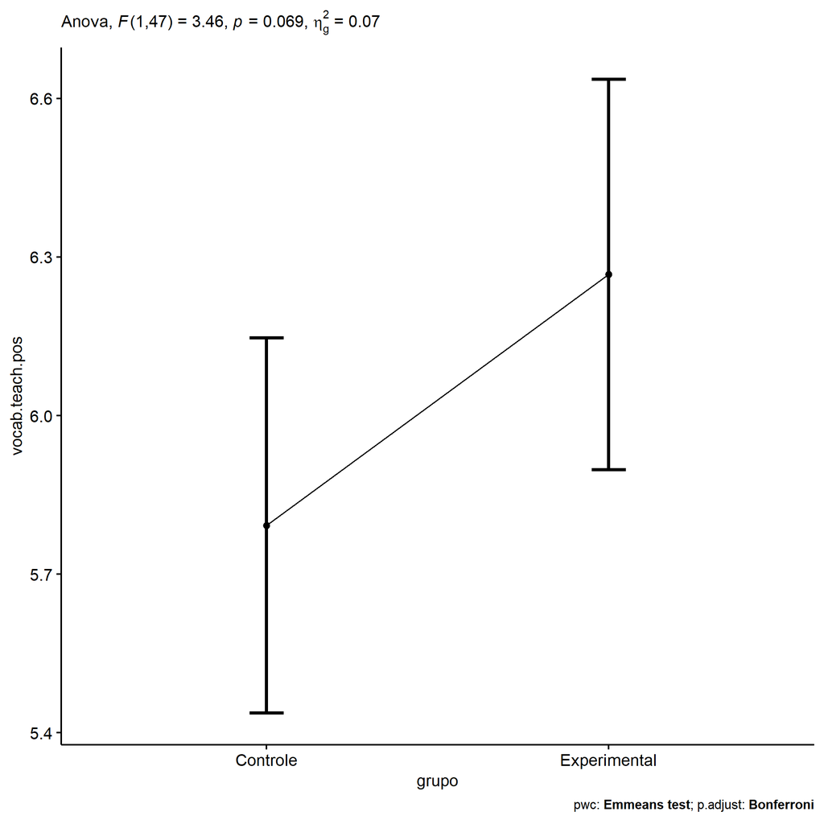

```r
if (!is.null(nrow(plots[["grupo"]]$data)))
  plots[["grupo"]] + ggplot2::scale_color_manual(values = color[["grupo"]])
```

```r
plots <- oneWayAncovaBoxPlots(
  wdat, "vocab.teach.pos", "grupo", aov, pwc, covar = "vocab.teach.pre",
  theme = "classic", color = color[["grupo"]],
  subtitle = which(aov$Effect == "grupo"))
```

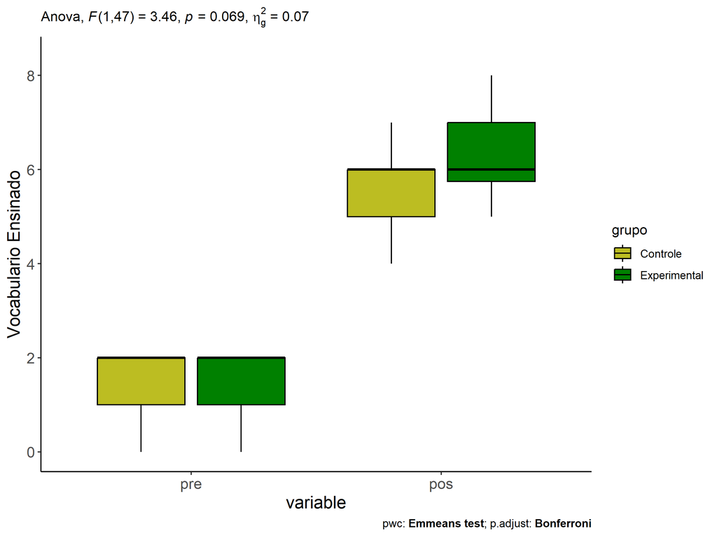

```r
if (length(unique(wdat[["grupo"]])) > 1)
  plots[["grupo"]] + ggplot2::ylab("Vocabulario Ensinado") + ggplot2::scale_x_discrete(labels=c('pre', 'pos'))
```

```r
if (length(unique(wdat.long[["grupo"]])) > 1)
  plots <- oneWayAncovaBoxPlots(
    wdat.long, "vocab.teach", "grupo", aov, pwc.long, pre.post = "time",
    theme = "classic", color = color$prepost)
```

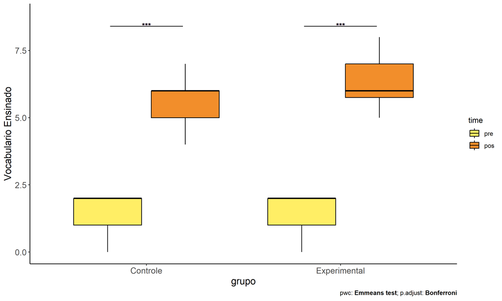

```r
if (length(unique(wdat.long[["grupo"]])) > 1)
  plots[["grupo"]] + ggplot2::ylab("Vocabulario Ensinado")
```

### Checking linearity assumption

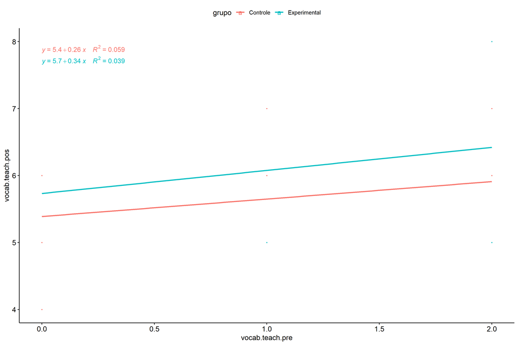

```r
ggscatter(wdat, x = "vocab.teach.pre", y = "vocab.teach.pos", size = 0.5,
          color = "grupo", add = "reg.line")+
  stat_regline_equation(
    aes(label =  paste(..eq.label.., ..rr.label.., sep = "~~~~"), color = grupo)
  )
```

### Checking normality and homogeneity

```r
res <- augment(lm(vocab.teach.pos ~ vocab.teach.pre + grupo, data = wdat))
```

```r
shapiro_test(res$.resid)
```

```
## # A tibble: 1 × 3
##   variable   statistic p.value
##   <chr>          <dbl>   <dbl>
## 1 res$.resid     0.958  0.0708
```

```r
levene_test(res, .resid ~ grupo)
```

```
## # A tibble: 1 × 4
##     df1   df2 statistic     p
##   <int> <int>     <dbl> <dbl>
## 1     1    48      1.37 0.248
```

# ANCOVA and Pairwise for two factors **grupo:Sexo**

## Without remove non-normal data

```r
pdat = remove_group_data(dat[!is.na(dat[["grupo"]]) & !is.na(dat[["Sexo"]]),], "vocab.teach.pos", c("grupo","Sexo"))

pdat.long <- rbind(pdat[,c("id","grupo","Sexo")], pdat[,c("id","grupo","Sexo")])
pdat.long[["time"]] <- c(rep("pre", nrow(pdat)), rep("pos", nrow(pdat)))
pdat.long[["time"]] <- factor(pdat.long[["time"]], c("pre","pos"))
pdat.long[["vocab.teach"]] <- c(pdat[["vocab.teach.pre"]], pdat[["vocab.teach.pos"]])

aov = anova_test(pdat, vocab.teach.pos ~ vocab.teach.pre + grupo*Sexo)
laov[["grupo:Sexo"]] <- get_anova_table(aov)
```

```r
pwcs <- list()
pwcs[["Sexo"]] <- emmeans_test(
  group_by(pdat, grupo), vocab.teach.pos ~ Sexo,
  covariate = vocab.teach.pre, p.adjust.method = "bonferroni")
pwcs[["grupo"]] <- emmeans_test(
  group_by(pdat, Sexo), vocab.teach.pos ~ grupo,
  covariate = vocab.teach.pre, p.adjust.method = "bonferroni")

pwc <- plyr::rbind.fill(pwcs[["grupo"]], pwcs[["Sexo"]])
pwc <- pwc[,c("grupo","Sexo", colnames(pwc)[!colnames(pwc) %in% c("grupo","Sexo")])]
```

```r
pwc.long <- emmeans_test(dplyr::group_by_at(pdat.long, c("grupo","Sexo")),
                         vocab.teach ~ time,
                         p.adjust.method = "bonferroni")
lpwc[["grupo:Sexo"]] <- plyr::rbind.fill(pwc, pwc.long)
```

```r
ds <- get.descriptives(pdat, "vocab.teach.pos", c("grupo","Sexo"), covar = "vocab.teach.pre")
ds <- merge(ds[ds$variable != "vocab.teach.pre",],
            ds[ds$variable == "vocab.teach.pre", !colnames(ds) %in% c("variable")],
            by = c("grupo","Sexo"), all.x = T, suffixes = c("", ".vocab.teach.pre"))
ds <- merge(get_emmeans(pwcs[["grupo"]]), ds, by = c("grupo","Sexo"), suffixes = c(".emms", ""))
ds <- ds[,c("grupo","Sexo","n","mean.vocab.teach.pre","se.vocab.teach.pre","mean","se","emmean","se.emms")]

colnames(ds) <- c("grupo","Sexo", "N", paste0(c("M","SE")," (pre)"),
                  paste0(c("M","SE"), " (unadj)"), paste0(c("M", "SE"), " (adj)"))

lemms[["grupo:Sexo"]] <- ds
```

## Computing ANCOVA and PairWise After removing non-normal data (OK)

```r
wdat = pdat

res = residuals(lm(vocab.teach.pos ~ vocab.teach.pre + grupo*Sexo, data = wdat))
non.normal = getNonNormal(res, wdat$id, plimit = 0.05)

wdat = wdat[!wdat$id %in% non.normal,]

wdat.long <- rbind(wdat[,c("id","grupo","Sexo")], wdat[,c("id","grupo","Sexo")])
wdat.long[["time"]] <- c(rep("pre", nrow(wdat)), rep("pos", nrow(wdat)))
wdat.long[["time"]] <- factor(wdat.long[["time"]], c("pre","pos"))
wdat.long[["vocab.teach"]] <- c(wdat[["vocab.teach.pre"]], wdat[["vocab.teach.pos"]])


ldat[["grupo:Sexo"]] = wdat

(non.normal)
```

```
##   [1] "P1065" "P852"  "P2438" "P631"  "P1112" "P3048" "P2133" "P1064" "P842"  "P1668" "P1050" "P1759"
##  [13] "P887"  "P871"  "P1066" "P1069" "P810"  "P961"  "P1754" "P967"  "P3029" "P2092" "P2908" "P817"
##  [25] "P539"  "P865"  "P1019" "P2121" "P1029" "P3265" "P856"  "P563"  "P2004" "P1656" "P489"  "P1998"
##  [37] "P1878" "P1008" "P1057" "P1892" "P3017" "P985"  "P442"  "P2143" "P2870" "P855"  "P835"  "P3180"
##  [49] "P1130" "P2096" "P529"  "P1027" "P917"  "P3493" "P3470" "P1807" "P1775" "P2967" "P2106" "P969"
##  [61] "P1788" "P549"  "P2882" "P2149" "P1039" "P3065" "P3262" "P2953" "P2189" "P3487" "P2162" "P1037"
##  [73] "P1616" "P1841" "P500"  "P971"  "P3130" "P889"  "P982"  "P2900" "P824"  "P1664" "P1997" "P873"
##  [85] "P1847" "P3461" "P3542" "P3257" "P2011" "P2068" "P1747" "P3119" "P3166" "P987"  "P3097" "P1714"
##  [97] "P915"  "P988"  "P3113" "P1691" "P1855" "P1696" "P823"  "P1080" "P2912" "P2980" "P3246" "P2903"
## [109] "P826"  "P3142" "P3573" "P1793" "P490"  "P1806" "P1591" "P3486" "P951"  "P2945" "P1911" "P2086"
## [121] "P1610" "P939"  "P2325" "P1974" "P3282" "P1671" "P2359" "P2472" "P1602" "P926"  "P1667" "P2879"
## [133] "P2168" "P1950" "P493"  "P1802" "P1074" "P1944" "P944"  "P488"  "P1738" "P886"  "P3043" "P2369"
## [145] "P3030" "P2223" "P973"  "P2242" "P472"  "P3536" "P1102" "P567"  "P3562" "P2907" "P2174" "P1859"
## [157] "P930"  "P473"  "P3033" "P1051" "P481"  "P1835" "P3053" "P520"  "P2082" "P864"  "P3309" "P3161"
```

```r
aov = anova_test(wdat, vocab.teach.pos ~ vocab.teach.pre + grupo*Sexo)
laov[["grupo:Sexo"]] <- merge(get_anova_table(aov), laov[["grupo:Sexo"]], by="Effect", suffixes = c("","'"))

(df = get_anova_table(aov))
```

```
## ANOVA Table (type II tests)
##
##            Effect DFn DFd     F     p p<.05   ges
## 1 vocab.teach.pre   1  23 0.573 0.457       0.024
## 2           grupo   1  23 1.010 0.325       0.042
## 3            Sexo   1  23 1.747 0.199       0.071
## 4      grupo:Sexo   0  23    NA    NA  <NA>    NA
```

| Effect | DFn | DFd | F | p | p<.05 | ges |
| --- | --- | --- | --- | --- | --- | --- |
| vocab.teach.pre | 1 | 23 | 0.573 | 0.457 |  | 0.024 |
| grupo | 1 | 23 | 1.010 | 0.325 |  | 0.042 |
| Sexo | 1 | 23 | 1.747 | 0.199 |  | 0.071 |
| grupo:Sexo | 0 | 23 |  |  |  |  |

```r
pwcs <- list()
pwcs[["Sexo"]] <- emmeans_test(
  group_by(wdat, grupo), vocab.teach.pos ~ Sexo,
  covariate = vocab.teach.pre, p.adjust.method = "bonferroni")
pwcs[["grupo"]] <- emmeans_test(
  group_by(wdat, Sexo), vocab.teach.pos ~ grupo,
  covariate = vocab.teach.pre, p.adjust.method = "bonferroni")

pwc <- plyr::rbind.fill(pwcs[["grupo"]], pwcs[["Sexo"]])
pwc <- pwc[,c("grupo","Sexo", colnames(pwc)[!colnames(pwc) %in% c("grupo","Sexo")])]
```

| grupo | Sexo | term | .y. | group1 | group2 | df | statistic | p | p.adj | p.adj.signif |
| --- | --- | --- | --- | --- | --- | --- | --- | --- | --- | --- |
|  | F | vocab.teach.pre*grupo | vocab.teach.pos | Controle | Experimental |  |  |  |  |  |
|  | M | vocab.teach.pre*grupo | vocab.teach.pos | Controle | Experimental | 23 | -1.005 | 0.325 | 0.325 | ns |
| Controle |  | vocab.teach.pre*Sexo | vocab.teach.pos | F | M | 23 | 1.322 | 0.199 | 0.199 | ns |
| Experimental |  | vocab.teach.pre*Sexo | vocab.teach.pos | F | M |  |  |  |  |  |

```r
pwc.long <- emmeans_test(dplyr::group_by_at(wdat.long, c("grupo","Sexo")),
                         vocab.teach ~ time,
                         p.adjust.method = "bonferroni")
lpwc[["grupo:Sexo"]] <- merge(plyr::rbind.fill(pwc, pwc.long), lpwc[["grupo:Sexo"]], by=c("grupo","Sexo","term",".y.","group1","group2"), suffixes = c("","'"))
```

| grupo | Sexo | term | .y. | group1 | group2 | df | statistic | p | p.adj | p.adj.signif |
| --- | --- | --- | --- | --- | --- | --- | --- | --- | --- | --- |
| Controle | F | time | vocab.teach | pre | pos | 48 | -9.046 | 0.000 | 0.000 | **** |
| Controle | M | time | vocab.teach | pre | pos | 48 | -2.161 | 0.036 | 0.036 | * |
| Experimental | F | time | vocab.teach | pre | pos |  |  |  |  |  |
| Experimental | M | time | vocab.teach | pre | pos | 48 | -5.539 | 0.000 | 0.000 | **** |

```r
ds <- get.descriptives(wdat, "vocab.teach.pos", c("grupo","Sexo"), covar = "vocab.teach.pre")
ds <- merge(ds[ds$variable != "vocab.teach.pre",],
            ds[ds$variable == "vocab.teach.pre", !colnames(ds) %in% c("variable")],
            by = c("grupo","Sexo"), all.x = T, suffixes = c("", ".vocab.teach.pre"))
ds <- merge(get_emmeans(pwcs[["grupo"]]), ds, by = c("grupo","Sexo"), suffixes = c(".emms", ""))
ds <- ds[,c("grupo","Sexo","n","mean.vocab.teach.pre","se.vocab.teach.pre","mean","se","emmean","se.emms")]

colnames(ds) <- c("grupo","Sexo", "N", paste0(c("M","SE")," (pre)"),
                  paste0(c("M","SE"), " (unadj)"), paste0(c("M", "SE"), " (adj)"))

lemms[["grupo:Sexo"]] <- merge(ds, lemms[["grupo:Sexo"]], by=c("grupo","Sexo"), suffixes = c("","'"))
```

| grupo | Sexo | N | M (pre) | SE (pre) | M (unadj) | SE (unadj) | M (adj) | SE (adj) |
| --- | --- | --- | --- | --- | --- | --- | --- | --- |
| Controle | F | 12 | 1.333 | 0.225 | 3.750 | 0.250 | 3.682 | 0.232 |
| Controle | M | 4 | 2.000 | 0.000 | 3.000 | 0.408 | 3.068 | 0.382 |
| Experimental | M | 11 | 1.909 | 0.091 | 3.455 | 0.157 | 3.504 | 0.233 |